# Chapter 3: Methods for Simulating Data

Statisticians (and other users of data) need to simulate data for many reasons.

For example, I simulate as a way to check whether a model is appropriate. If the observed data are similar to the data I generated, then this is one way to show my model may be a good one.

It is also sometimes useful to simulate data from a distribution when I need to estimate an expected value (approximate an integral).

`R` can already generate data from many (named) distributions:

```r
set.seed(400) #reproducibility

rnorm(10) # 10 observations of a N(0,1) r.v.
```

```
##  [1] -1.0365488  0.6152833  1.4729326 -0.6826873 -0.6018386 -1.3526097
##  [7]  0.8607387  0.7203705  0.1078532 -0.5745512
```

```r
rnorm(10, 0, 5) # 10 observations of a N(0,5^2) r.v.
```

```
##  [1] -4.5092359  0.4464354 -7.9689786 -0.4342956 -5.8546081  2.7596877
##  [7] -3.2762745 -2.1184014  2.8218477 -5.0927654
```

```r
rexp(10) # 10 observations from an Exp(1) r.v.
```

```
##  [1] 0.67720831 0.04377997 5.38745038 0.48773005 1.18690322 0.92734297
##  [7] 0.33936255 0.99803323 0.27831305 0.94257810
```

**But what about when we don’t have a function to do it?**

# 1 Inverse Transform Method

**Theorem 1.1 (Probability Integral Transform)** If $X$ is a continuous r.v. with cdf $F_X$, then $U = F_X(X) \sim \text{Uniform}[0, 1]$.

This leads to to the following method for simulating data.

**Inverse Transform Method**:

First, generate $u$ from Uniform$[0,1]$. Then, $x = F_X^{-1}(u)$ is a realization from $F_X$.

**Note:**

## 1.1 Algorithm

1. Derive the inverse function $F_X^{-1}$.
2. Write a function to compute $x = F_X^{-1}(u)$.
3. For each realization,

**Example 1.1** Simulate a random sample of size $1000$ from the pdf $f_X(x) = 3x^2, 0 \le x \le 1$.

3. ```r
   # write code for inverse transform example
   # f_X(x) = 3x^2, 0 <= x \<= 1
   ```

## 1.2 Discrete RVs

If $X$ is a discrete random variable and $\cdots < x_{i-1} < x_i < \cdots$ are the points of discontinuity of $F_X(x)$, then the inverse transform is $F_X^{-1}(u) = x_i$ where $F_X(x_{i-1}) < u \le F_X(x_i)$. This leads to the following algorithm:

1. Generate a r.v. $U$ from Unif$(0,1)$.
2. Select $x_i$ where $F_X(x_{i-1}) < U \le F_X(x_{i})$.

**Example 1.2** Generate 1000 samples from the following discrete distribution.

```r
x <- 1:3
p <- c(0.1, 0.2, 0.7)
```

| x | 1.0 | 2.0 | 3.0 |
| --- | --- | --- | --- |
| f | 0.1 | 0.2 | 0.7 |

```r
# write code to sample from discrete dsn
n <- 1000
```

# 2 Acceptance-Reject Method

The goal is to generate realizations from a *target density*, $f$.

Most cdfs cannot be inverted in closed form.

The Acceptance-Reject (or “Accept-Reject”) samples from a distribution that is *similar* to $f$ and then adjusts by only accepting a certain proportion of those samples.

The method is outlined below:

Let $g$ denote another density from which we **know how to sample** and we can **easily calculate $g(x)$**.

Let $e(\cdot)$ denote an *envelope*, having the property $e(x) = c g(x) \ge f(x)$ for all $x \in \mathcal{X} = \{x:f(x) > 0\}$ for a given constant $c \ge 1$.

The Accept-Reject method then follows by sampling $Y \sim g$ and $U \sim \text{Unif}(0,1)$.

If $U < f(Y)/e(Y)$, accept $Y$. Set $X = Y$ and consider $X$ to be an element of the target random sample.

**Note:** $1/c$ is the expected proportion of candidates that are accepted.

## 2.1 Algorithm

1. Find a suitable density $g$ and envelope $e$.
2. Sample $Y \sim g$.
3. Sample $U \sim \text{Unif}(0, 1)$.
4. If $U < f(Y)/e(Y)$, accept $Y$.
5. Repeat from Step 2 until you have generated your desired sample size.

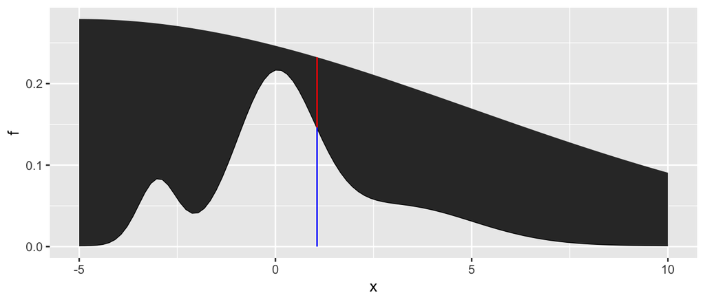

## 2.2 Envelopes

Good envelopes have the following properties:

A simple approach to finding the envelope:

**Example 2.1** We want to generate a random variable with pdf $f(x) = 60x^3(1-x)^2$, $0 \le x \le 1$. This is a Beta$(4, 3)$ distribution.

Can we invert $F(x)$ analytically?

If not, find the maximum of $f(x)$.

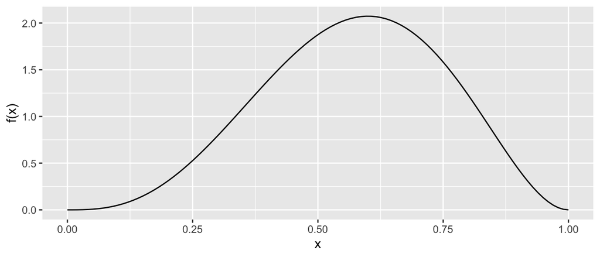

```r
# pdf function, could use dbeta() instead
f <- function(x) {
    60*x^3*(1-x)^2
}

# plot pdf
x <- seq(0, 1, length.out = 100)
ggplot() +
  geom_line(aes(x, f(x)))
```

```r
envelope <- function(x) {
  ## create the envelope function
}

# Accept reject algorithm
n <- 1000 # number of samples wanted
accepted <- 0 # number of accepted samples
samples <- rep(NA, n) # store the samples here

while(accepted < n) {
  # sample y from g

  # sample u from uniform(0,1)
  u <- runif(1)

  if(u < f(y)/envelope(y)) {
    # accept
    accepted <- accepted + 1
    samples[accepted] <- y
  }
}
```

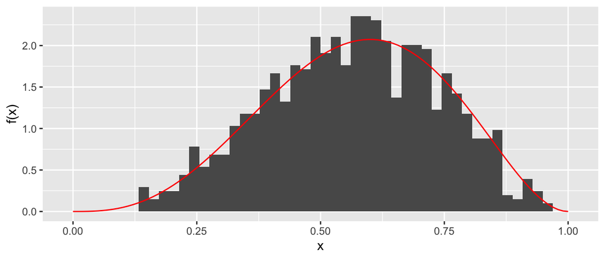

```r
ggplot() +
  geom_histogram(aes(sample, y = ..density..), bins = 50, ) +
  geom_line(aes(x, f(x)), colour = "red") +
  xlab("x") + ylab("f(x)")
```

## 2.3 Why does this work?

Recall that we require
$$cg(y) \ge f(y) \qquad \forall y \in \{y: f(y) > 0\}.$$
Thus,

The larger the ratio $\frac{f(y)}{cg(y)}$, the more the random variable $Y$ looks like a random variable distributed with pdf $f$ and the more likely $Y$ is to be accepted.

## 2.4 Additional Resources

See p.g. 69-70 of Rizzo for a proof of the validity of the method.

# 3 Transformation Methods

We have already used one transformation method – **Inverse transform method** – but there are many other transformations we can apply to random variables.

1. If $Z \sim N(0, 1)$, then $V = Z^2 \sim$
2. If $U \sim \chi^2_{m}$ and $V \sim \chi^2_{n}$ are independent, then $F = \frac{U/m}{V/n} \sim$
3. If $Z \sim N(0, 1)$ and $V \sim \chi^2_{n}$ are independendent, then $T = \frac{Z}{\sqrt{V/n}}\sim$
4. If $U \sim \text{Gamma}(r, \lambda)$ and $V \sim \text{Gamma}(s, \lambda)$ are independent, then $X = \frac{U}{U + V}\sim$

**Definition 3.1** A *transformation* is any function of one or more random variables.

Sometimes we want to transform random variables if observed data don’t fit a model that might otherwise be appropriate. Sometimes we want to perform inference about a new statistic.

**Example 3.1** If $X_1, \dots, X_n \stackrel{iid}{\sim} \text{Bernoulli}(p)$. What is the distribution of $\sum_{i = 1}^n X_i$?

**Example 3.2** If $X\sim N(0,1)$, what is the distribution of $X + 5$?

**Example 3.3** For $X_1, \dots, X_n$ iid random variables, what is the distribution of the median of $X_1, \dots, X_n$? What is the distribution of the order statistics? $X_{[i]}$?

There are many approaches to deriving the pdf of a transformed variable.

But the theory isn’t always available. What can we do?

## 3.1 Algorithm

Let $X_1, \dots, X_p$ be a set of independent random variables with pdfs $f_{X_1}, \dots, f_{X_p}$, respectively, and let $g(X_1, \dots, X_p)$ be some transformation we are interested in simulating from.

1. Simulate $X_1 \sim f_{X_1}, \dots, X_p \sim f_{X_p}$.
2. Compute $G = g(X_1, \dots, X_p)$. This is one draw from $g(X_1, \dots, X_p)$.
3. Repeat Steps 1-2 many times to simulate from the target distribution.

**Example 3.4** It is possible to show for $X_1, \dots, X_p \stackrel{iid}{\sim} N(0,1)$, $Z = \sum_{i = 1}^p X_i^2 \sim \chi^2_p$. Imagine that we cannot use the `rchisq` function. How would you simulate $Z$?

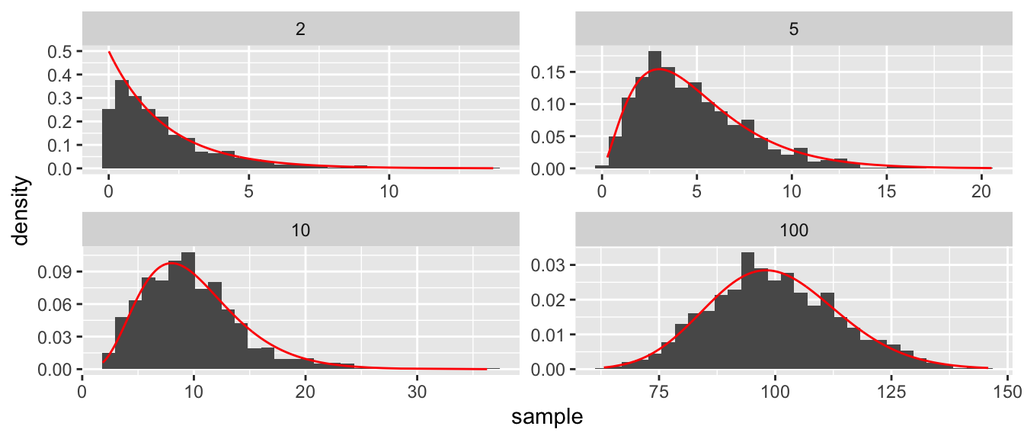

```r
library(tidyverse)

# function for squared r.v.s
squares <- function(x) x^2

sample_z <- function(n, p) {
  # store the samples
  samples <- data.frame(matrix(rnorm(n*p), nrow = n))

  samples %>%
    mutate_all("squares") %>% # square the rvs
    rowSums() # sum over rows
}

# get samples
n <- 1000 # number of samples

# apply our function over different degrees of freedom
samples <- data.frame(chisq_2 = sample_z(n, 2),
                      chisq_5 = sample_z(n, 5),
                      chisq_10 = sample_z(n, 10),
                      chisq_100 = sample_z(n, 100))

# plot results
samples %>%
  gather(distribution, sample, everything()) %>% # make easier to plot w/ facets
  separate(distribution, into = c("dsn_name", "df")) %>% # get the df
  mutate(df = as.numeric(df)) %>% # make numeric
  mutate(pdf = dchisq(sample, df)) %>% # add density function values
  ggplot() + # plot
  geom_histogram(aes(sample, y = ..density..)) + # samples
  geom_line(aes(sample, pdf), colour = "red") + # true pdf
  facet_wrap(~df, scales = "free")
```

# 4 Mixture Distributions

The `faithful` dataset in `R` contains data on eruptions of Old Faithful (Geyser in Yellowstone National Park).

```r
head(faithful)
```

```
##   eruptions waiting
## 1     3.600      79
## 2     1.800      54
## 3     3.333      74
## 4     2.283      62
## 5     4.533      85
## 6     2.883      55
```

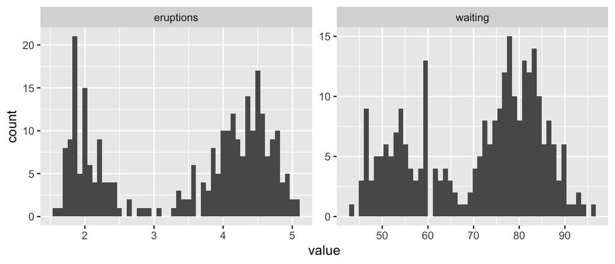

```r
faithful %>%
  gather(variable, value) %>%
  ggplot() +
  geom_histogram(aes(value), bins = 50) +
  facet_wrap(~variable, scales = "free")
```

What is the shape of these distributions?

**Definition 4.1** A random variable $Y$ is a discrete mixture if the distribution of $Y$ is a weighted sum $F_Y(y) = \sum \theta_i F_{X_i}(y)$ for some sequence of random variables $X_1, X_2, \dots$ and $\theta_i > 0$ such that $\sum \theta_i = 1$.

For $2$ r.v.s,

**Example 4.1**

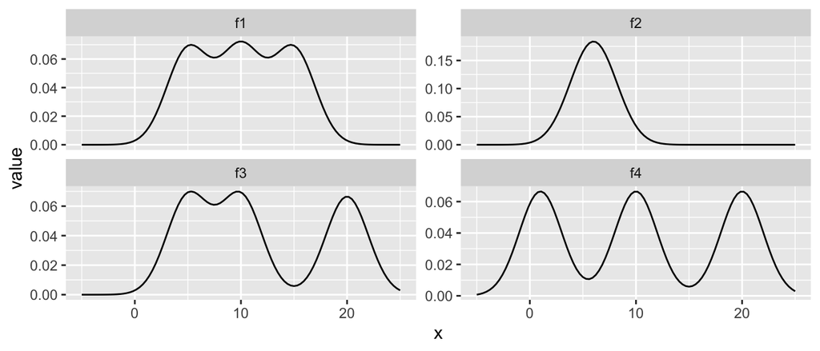

```r
x <- seq(-5, 25, length.out = 100)

mixture <- function(x, means, sd) {
  # x is the vector of points to evaluate the function at
  # means is a vector, sd is a single number
  f <- rep(0, length(x))
  for(mean in means) {
    f <- f + dnorm(x, mean, sd)/length(means) # why do I divide?
  }
  f
}

# look at mixtures of N(mu, 4) for different values of mu
data.frame(x,
           f1 = mixture(x, c(5, 10, 15), 2),
           f2 = mixture(x, c(5, 6, 7), 2),
           f3 = mixture(x, c(5, 10, 20), 2),
           f4 = mixture(x, c(1, 10, 20), 2)) %>%
  gather(mixture, value, -x) %>%
  ggplot() +
  geom_line(aes(x, value)) +
  facet_wrap(.~mixture, scales = "free_y")
```

## 4.1 Mixtures vs. Sums

Note that mixture distributions are *not* the same as the distribution of a sum of r.v.s.

**Example 4.2** Let $X_1 \sim N(0, 1)$ and $X_2 \sim N(4, 1)$, independent.

$S = \frac{1}{2}(X_1 + X_2)$

$Z$ such that $f_Z(z) = 0.5f_{X_1}(z) + 0.5f_{X_2}(z)$.

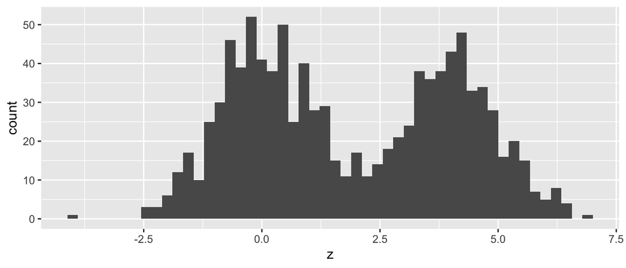

```r
n <- 1000
u <- rbinom(n, 1, 0.5)

z <- u*rnorm(n) + (1 - u)*rnorm(n, 4, 1)

ggplot() +
  geom_histogram(aes(z), bins = 50)
```

What about $f_Z(z) = 0.7f_{X_1}(z) + 0.3f_{X_2}(z)$?

## 4.2 Models for Count Data (refresher)

Recall that the Poisson$(\lambda)$ distribution is useful for modeling count data.

$$f(x) = \frac{\lambda^x \exp\{-\lambda\}}{x!}, \quad x = 0, 1, 2, \dots$$
Where $X =$ number of events occuring in a fixed period of time or space.

When the mean $\lambda$ is low, then the data consists of mostly low values (i.e. $0, 1, 2$, etc.) and less frequently higher values.

As the mean count increases, the skewness goes away and the distribution becomes approximately normal.

With the Poisson distribution,
$$E[X] = Var X = \lambda.$$

**Example 4.3**

**Example 4.4** The Colorado division of Parks and Wildlife has hired you to analyze their data on the number of fish caught in Horsetooth resevoir by visitors. Each visitor was asked - How long did you stay? - How many fish did you catch? - Other questions: How many people in your group, were children in your group, etc.

Some visiters do not fish, but there is not data on if a visitor fished or not. Some visitors who did fish did not catch any fish.

Note, this is modified from https://stats.idre.ucla.edu/r/dae/zip/.

```r
fish <- read_csv("https://stats.idre.ucla.edu/stat/data/fish.csv")
```

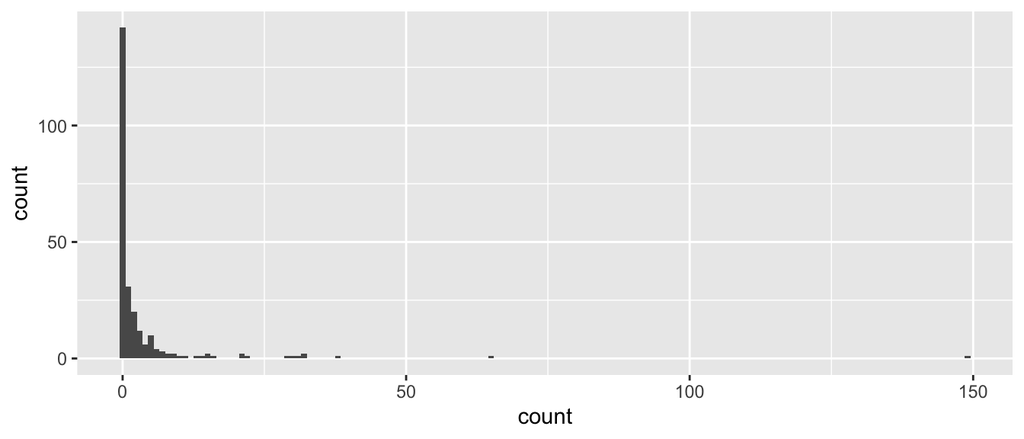

```r
# with zeroes
ggplot(fish) + geom_histogram(aes(count), binwidth = 1)
```

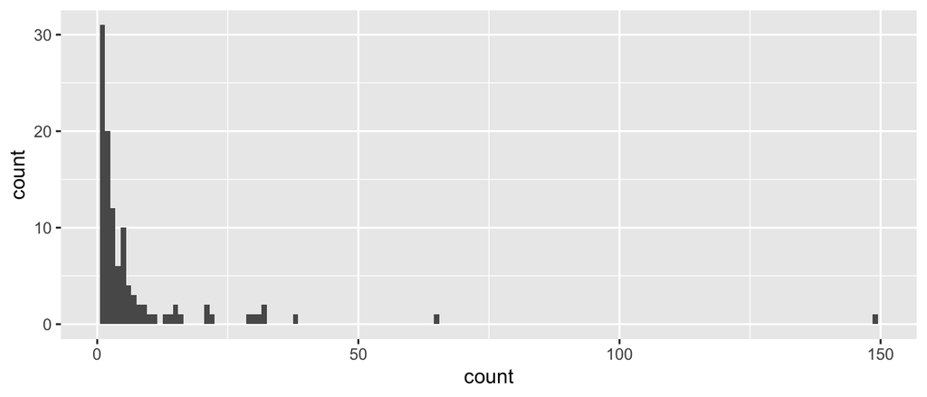

```r
# without zeroes
fish %>%
  filter(count > 0) %>%
  ggplot() +
  geom_histogram(aes(count), binwidth = 1)
```

A *zero-inflated* model assumes that the zero observations have two different origins – structural and sampling zeroes.

**Example 4.5**

A zero-inflated model is a **mixture model** because the distribution is a weighted average of the sampling model (i.e. Poisson) and a point-mass at $0$.

For $Y\sim ZIP(\lambda)$,

$$Y \sim \begin{cases}
0 & \text{with probability } \pi \\
\text{Poisson}(\lambda) & \text{with probability } 1-\pi
\end{cases}$$
So that,

$$Y = \qquad \qquad\qquad\qquad\qquad\qquad\qquad\qquad\qquad\qquad\qquad\qquad$$

To simulate from this distribution,

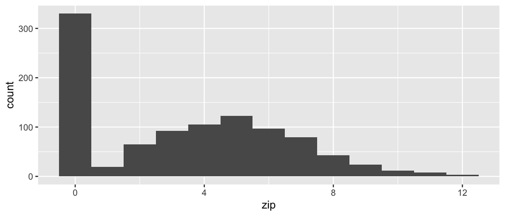

```r
n <- 1000
lambda <- 5
pi <- 0.3

u <- rbinom(n, 1, pi)
zip <- u*0 + (1-u)*rpois(n, lambda)

# zero inflated model
ggplot() + geom_histogram(aes(zip), binwidth = 1)
```

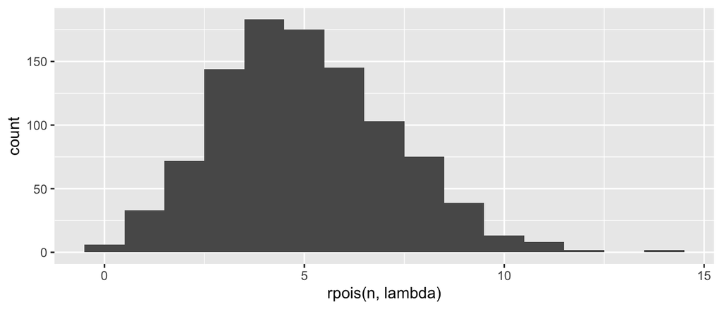

```r
# Poisson(5)
ggplot() + geom_histogram(aes(rpois(n, lambda)), binwidth = 1)
```